# PML: Weightlifting Movement Error Prediction Assignment

# FURTHER MODEL DEVELOPMENT, COMPARISON AND SELECTION

Now let’s try varying the number of components of the PCA to find an optimal number.

```r
## Let's try using random forests on an 11 component PCA (takes even longer...!)
mfit_PC11_1 <- train(pmltraint$classe ~ ., method="rf", data=trainPC11)

## Let's get predicted values for the verification data and evaluate the model
verifPC11_1 <- predict(preP11, pmltrainv)
confusionMatrix(pmltrainv$classe, predict(mfit_PC11_1, verifPC11_1))$overall['Accuracy']
```

```
##  Accuracy
## 0.9663523
```

```r
## Now let's try 12 components (takes some time...)
mfit_PC12_1 <- train(pmltraint$classe ~ ., method="rf", data=trainPC12)

## Let's get predicted values for the verification data and evaluate the model
verifPC12_1 <- predict(preP12, pmltrainv)
confusionMatrix(pmltrainv$classe, predict(mfit_PC12_1, verifPC12_1))$overall['Accuracy']
```

```
##  Accuracy
## 0.9640581
```

```r
## Now let's try 13 components (takes some time...)
mfit_PC13_1 <- train(pmltraint$classe ~ ., method="rf", data=trainPC13)

## Let's get predicted values for the verification data and evaluate the model
verifPC13_1 <- predict(preP13, pmltrainv)
confusionMatrix(pmltrainv$classe, predict(mfit_PC13_1, verifPC13_1))$overall['Accuracy']
```

```
##  Accuracy
## 0.9666072
```

```r
## Which components are most important?
varImp(mfit_PC13_1)
```

```
## rf variable importance
##
##      Overall
## PC7   100.00
## PC1    95.76
## PC3    72.28
## PC4    71.45
## PC13   69.84
## PC12   67.59
## PC5    66.77
## PC9    64.27
## PC2    49.08
## PC8    38.33
## PC6    32.92
## PC10   28.24
## PC11    0.00
```

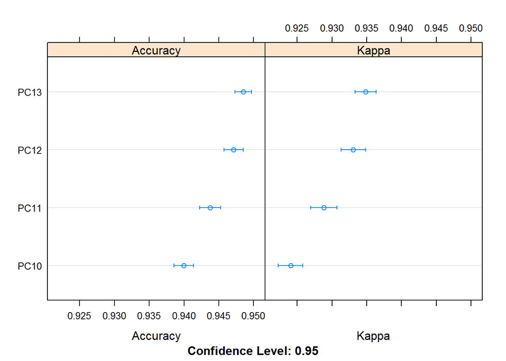

```r
## Let's compare the Accuracy of these models now
results <- resamples(list(PC10=mfit_PC10_1, PC11=mfit_PC11_1, PC12=mfit_PC12_1, PC13=mfit_PC13_1))
dotplot(results)
```

Up to the 12th component, the 95% confidence intervals of the accuracy estimates do not overlap. However, the CI of the accuracy estimate of the 13 PC models overlaps with that of the 12 PC model. Thus, we will use the model with 12 PCs, since additional components will have negligible impact and may lead to overfitting of the model to the training data set, and concommitantly, to lower accuracy on subsequent new data sets.

```r
## Let's see a plot of the data by the most imporant three components
## First, create a color coding for the error classification
w <- mfit_PC12_1$finalModel[['y']]
cols <- rainbow(5)[as.numeric(w)]

## Plot the components and add a legend for the error classification
plot3d(mfit_PC12_1$trainingData[['PC12']],mfit_PC12_1$trainingData[['PC8']],mfit_PC12_1$trainingData[['PC5']], xlab="PC12", ylab="PC8", zlab="PC5", col=cols)
legend3d("topright", c("A", "B", "C", "D", "E"), pch=16, col=unique(cols))

## Review final model
mfit_PC12_1$finalModel
```

```
##
## Call:
##  randomForest(x = x, y = y, mtry = param$mtry)
##                Type of random forest: classification
##                      Number of trees: 500
## No. of variables tried at each split: 2
##
##         OOB estimate of  error rate: 3.71%
## Confusion matrix:
##      A    B    C    D    E class.error
## A 4369   24   39   30    2  0.02128136
## B   61 2888   71    5   13  0.04937459
## C   29   35 2627   32   15  0.04054054
## D   24    4  101 2434   10  0.05402254
## E   12   28   24   24 2798  0.03049203
```

[interactive chart not shown]

# TEST DATA PREDICTION

Let’s apply this model to predict the error types of the 20 test cases.

```r
## First we need to calculate the principal components for this test data
testPC12 <- predict(preP12, pmltest)

## Now we can predict the error types of these cases
FinPred <- predict(mfit_PC12_1, testPC12)
print(FinPred)
```

```
##  [1] B A A A A E D B A A A C B A E E A B B B
## Levels: A B C D E
```

Finally, here is a reminder of the interpretations of these types of unilateral bicep dumbell curl: (A) correctly, (B) throwing elbows forward, (C) lifting only halfway, (D) lowering only halfway, (E) throwing hips forward.